# quantum_EM

### Imports

```python
import json
import math
import matplotlib.pyplot as plt
import numpy as np
from sklearn import datasets

from qiskit import ClassicalRegister, QuantumCircuit, QuantumRegister
from qiskit.circuit.library import PauliFeatureMap, ZFeatureMap, ZZFeatureMap

from qiskit.opflow import X, Y, Z, I, CircuitStateFn
from qiskit.opflow.state_fns import StateFn
from qiskit.opflow.expectations import PauliExpectation, MatrixExpectation
from qiskit.opflow.converters import CircuitSampler
from qiskit.providers.aer import QasmSimulator
```

### Definizione dei dati

Dati sintetici per testare l'esecuzione del codice

```python
DATA = np.array([[0.8, 0.8, 0.8, 0.8], [1, 1, 1, 1]])
FEATURES = DATA.shape[1]
SIZE = DATA.shape[0]
```

### Circuito enconding

Viene utilizzata una ZZFeatureMap

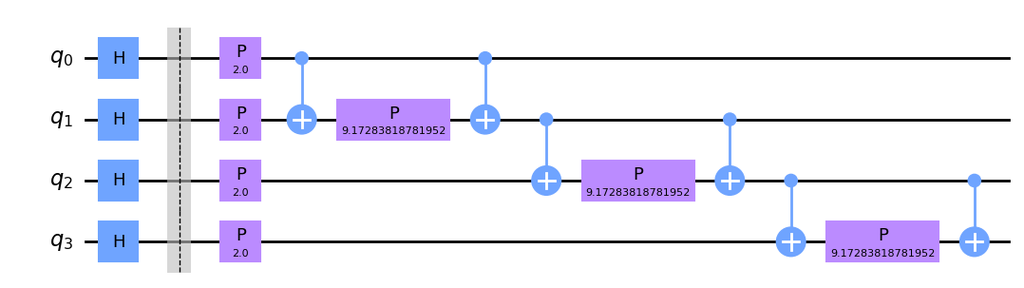

```python
encode_map = ZZFeatureMap(feature_dimension=FEATURES, reps=1, entanglement='linear', insert_barriers=True)
encode_circuit = encode_map.bind_parameters(DATA[1])
encode_circuit.decompose().draw(output='mpl')
```

## EM Distance

Dati due stati $|\psi>$ e $|\phi>$, si definisce la distanza EM approssimata come:

$ \widetilde{D}_{EM} = max_{H_i}| <\phi|H| \phi> - <\psi|H| \psi>| : ||H||_L \leq 1 $

dato $O_n$ insieme degli observbles su n qbit, si definisce $H$

$ H \in O_n : ||H||_L = 2 max_{i = 1,\dots,n} (min\{{||H- H_i ||_{\inf} : H_i \in O_n \text{ identità sull'iesimo qbit}}\}) $

Il valore $<\phi|H| \phi>$ equivale al calcolo dell'expectation dell'osservable H rispetto allo stato $|\phi>$

### Esecuzione passo passo

generate_pauli(n): Genera le combinazioni di operatori pauli (X,Y,Z) sui singoli qbit per generare un subset di obsevables con constante di lipshitz minore o uguale a 1

Nello specifico, gli observables presi in considerazione sono:

- Pauli Z per ogni qbit
- Per ogni qbit k:
  - Per ogni qbit j < k applico Pauli X
  - Per il qbit k applico Pauli X se PARI e Pauli Y se DISPARI
  - Per ogni qbit k < j applico Pauli Z

Vegono considerate quindi n+1 osservabili. Ad esempio, per n=4 qbit verrano generati i gate: ZZZZ, YZZZ, XXZZ, XXYZ, XXXX

```python
def even(x):
    return (x % 2) == 0


def generate_pauli(n):
    hamiltonians = []

    h = 1
    for _ in range(n):
        h = h^Z
    hamiltonians.append(h)

    for k in range(n):

        h = 1

        if(k != 0):
            for _ in range(k):
                h = h^X

        if even(k+1):
            h = h^X
        else:
            h = h^Y

        if (k+1 != n):
            for _ in range(k+1, n):
                h = h^Z


        hamiltonians.append(h)

    return hamiltonians
```

Compongo il circuito per i due vettori da confrontare.

Dati due vettori x,y viene applicata una ZZFeature map per l'encoding rispettivamente nei stati $|\psi>$ e $|\phi>$.

Viene successivamente composto il circuito che calcola: $<\phi|H| \phi>$ e $<\psi|H| \psi>$

con H matrice generata dalla funzione generate_pauli

```python
x = CircuitStateFn(encode_map.bind_parameters(DATA[0]))
y = CircuitStateFn(encode_map.bind_parameters(DATA[1]))
n = x.num_qubits

observables = generate_pauli(n)

circuit = x.adjoint().compose(observables[4]).compose(x)

print(circuit)
```

```
ComposedOp([
  CircuitMeasurement(
       ┌────────────────────────────────┐┌──────────────┐»
  q_0: ┤0                               ├┤0             ├»
       │                                ││              │»
  q_1: ┤1                               ├┤1             ├»
       │  ZZFeatureMap(0.8,0.8,0.8,0.8) ││  Pauli(XXXX) │»
  q_2: ┤2                               ├┤2             ├»
       │                                ││              │»
  q_3: ┤3                               ├┤3             ├»
       └────────────────────────────────┘└──────────────┘»
  «     ┌───────────────────────────────────┐
  «q_0: ┤0                                  ├
  «     │                                   │
  «q_1: ┤1                                  ├
  «     │  ZZFeatureMap_dg(0.8,0.8,0.8,0.8) │
  «q_2: ┤2                                  ├
  «     │                                   │
  «q_3: ┤3                                  ├
  «     └───────────────────────────────────┘
  ),
  DictStateFn({'0000': 1})
])
```

```python
max = 0

for h in observables:

    print(f"Obeservable [{h}]")
    circuit_x = x.adjoint().compose(h).compose(x)
    circuit_y = y.adjoint().compose(h).compose(y)

    EM = abs(circuit_x.eval().real - circuit_y.eval().real)

    print(f'''EM Distance
       |E(x) - E(y)| = {abs(circuit_x.eval().real - circuit_y.eval().real)}''')

    print('\n')

print(f"Final EM: {max}")
```

```
Obeservable [ZZZZ]
EM Distance
       |E(x) - E(y)| = 0.0


Obeservable [YZZZ]
EM Distance
       |E(x) - E(y)| = 0.0


Obeservable [XXZZ]
EM Distance
       |E(x) - E(y)| = 0.0


Obeservable [XXYZ]
EM Distance
       |E(x) - E(y)| = 0.01799009887524796


Obeservable [XXXX]
EM Distance
       |E(x) - E(y)| = 0.02998995839471978


Final EM: 0
```

### EM Distance function

Calcolo della distanza con data enconding usando una ZZFeature map

```python
def em_distance_approximate(data_1, data_2, encode_map, observables, simulator):

    x = CircuitStateFn(encode_map.bind_parameters(data_1))
    y = CircuitStateFn(encode_map.bind_parameters(data_2))

    em = 0

    for h in observables:

        measurable_x = StateFn(h, is_measurement=True).compose(x)
        measurable_y = StateFn(h, is_measurement=True).compose(y)

        expectation_x = PauliExpectation().convert(measurable_x)
        expectation_y = PauliExpectation().convert(measurable_y)

        sampler_x = CircuitSampler(simulator).convert(expectation_x)
        sampler_y = CircuitSampler(simulator).convert(expectation_y)

        current_expectation = abs(sampler_x.eval().real - sampler_y.eval().real)

        if current_expectation > em:
            em = current_expectation

    return em

def em_distance_exact(data_1, data_2, encode_map, observables):

    x = CircuitStateFn(encode_map.bind_parameters(data_1))
    y = CircuitStateFn(encode_map.bind_parameters(data_2))

    em = 0

    for h in observables:

        circuit_x = x.adjoint().compose(h).compose(x)
        circuit_y = y.adjoint().compose(h).compose(y)

        current_expectation = abs(circuit_x.eval().real - circuit_y.eval().real)

        if current_expectation > em:
            em = current_expectation

    return em


def em_dissimilarity_matrix(dataset, approximate = False):

    encode_map = ZZFeatureMap(feature_dimension=dataset.shape[1], reps=1, entanglement='linear', insert_barriers=True)
    n = encode_map.num_qubits
    observables = generate_pauli(n)
    mat = np.zeros((dataset.shape[0], dataset.shape[0]))

    if approximate:
        simulator = QasmSimulator()

        for i in range(dataset.shape[0]):
            for j in range(i):
                dis = em_distance_approximate(dataset[i], dataset[j], encode_map, observables, simulator)
                mat[i,j] = dis
                mat[j,i] = dis
    else:

        for i in range(dataset.shape[0]):
            for j in range(i):
                dis = em_distance_exact(dataset[i], dataset[j], encode_map, observables)
                mat[i,j] = dis
                mat[j,i] = dis

    return mat

def euclidean_matrix(dataset):
    mat = np.zeros((dataset.shape[0], dataset.shape[0]))

    for i in range(dataset.shape[0]):
        for j in range(i):
            dis = np.sqrt(np.sum((dataset[i] - dataset[j])**2))
            mat[i,j] = dis
            mat[j,i] = dis

    return mat


def manhattan_matrix(dataset):
    mat = np.zeros((dataset.shape[0], dataset.shape[0]))

    for i in range(dataset.shape[0]):
        for j in range(i):
            dis = np.sum(np.abs(dataset[i] - dataset[j]))
            mat[i,j] = dis
            mat[j,i] = dis

    return mat
```

```python
iris = datasets.load_iris()['data'][15:35, :]
em_matrix = em_dissimilarity_matrix(iris, approximate=False)
```

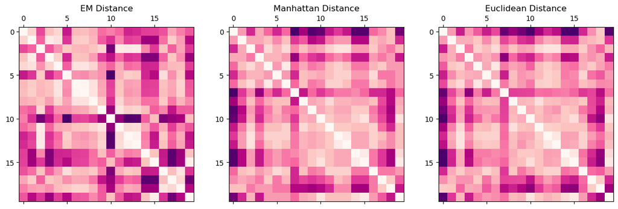

```python
%matplotlib inline

fig, axs = plt.subplots(1,3)
fig.set_size_inches(15,6)

axs[0].matshow(em_matrix, cmap='RdPu')
axs[0].set_title("EM Distance")
axs[1].matshow(manhattan_matrix(iris), cmap='RdPu')
axs[1].set_title("Manhattan Distance")
axs[2].matshow(euclidean_matrix(iris), cmap='RdPu')
axs[2].set_title("Euclidean Distance")

fig.show()
```

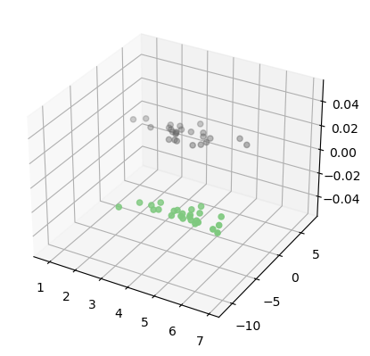

```python
blobs, classes = datasets.make_blobs(n_samples=50, random_state=10, n_features=2, centers=2)
blobs = np.array(blobs)

fig = plt.figure()
ax = fig.add_subplot(projection='3d')
ax.scatter(blobs[:,0], blobs[:,1], c=classes, cmap="Accent")
```

```python
em_matrix = em_dissimilarity_matrix(blobs)
```

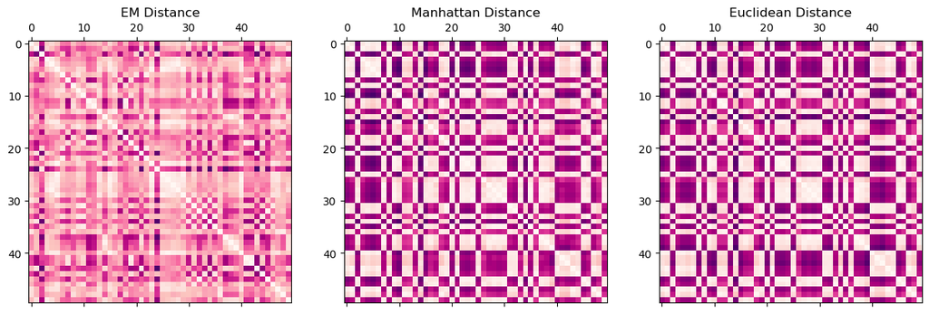

```python
%matplotlib inline

fig, axs = plt.subplots(1,3)
fig.set_size_inches(15,6)

axs[0].matshow(em_matrix, cmap='RdPu')
axs[0].set_title("EM Distance")
axs[1].matshow(manhattan_matrix(blobs), cmap='RdPu')
axs[1].set_title("Manhattan Distance")
axs[2].matshow(euclidean_matrix(blobs), cmap='RdPu')
axs[2].set_title("Euclidean Distance")

fig.show()
```